# VeRisk Yee-Haw Foods Analysis

### In this study, we will review data provided by VeRisk and provide an data analysis of Yee-Haw Foods. We will comment the following during this analysis:

- *The primary factors that drive (and those that don’t drive) Yee-Haw transaction volume.*
- *The overall predictability of Yee-Haw transaction volume as a driver for inventory and resource planning.*
- *Methodologies for modeling daily Yee-Haw transaction volume in real-time going forward.*
- *Methodologies for making regular algorithmic recommendations for inventory and resource planning.*
- *Questions that you would like to ask the Yee-Haw management team that would assist the project if your team gets the go-ahead (this might include a request for additional data).*

## Agenda

- **Data Exploration and Findings**
  - Determine primary factors that drive transaction volume
- **Apply Machine Learning Algorithms**
  - Regressor Algorithms
- **Significance Testing and Model Selection**
  - Linear Regression and ANOVA
- **Questions**

```python
import pandas as pd
import numpy as np
import seaborn as sns
import pickle
from matplotlib import pyplot as plt
%matplotlib inline
```

```python
#load DataFrames
df = pickle.load(open("../database/df.pkl","rb"))
df1 = pickle.load(open("../database/df1.pkl","rb"))
df_ml = pickle.load(open("../database/df_ml.pkl","rb"))
df1_ml = pickle.load(open("../database/df1_ml.pkl","rb"))
df.iloc[:,0:7].head()
```

|  | merchantstate | transdate | TransactionIndex | PRCP | SNWD | TMAX | TMIN |
| --- | --- | --- | --- | --- | --- | --- | --- |
| 0 | TX | 1/1/13 | 0.402095 | 0.045276 | 0 | 56.03 | 40.01 |
| 1 | TX | 1/2/13 | 0.465669 | 0.000000 | 0 | 42.44 | 34.61 |
| 2 | TX | 1/3/13 | 0.472393 | 0.000000 | 0 | 51.53 | 32.54 |
| 3 | TX | 1/4/13 | 0.489343 | 0.005906 | 0 | 50.54 | 41.00 |
| 4 | TX | 1/5/13 | 0.528285 | 0.389764 | 0 | 49.46 | 39.02 |

```python
df.iloc[:,0:7].describe()
```

|  | TransactionIndex | PRCP | SNWD | TMAX | TMIN |
| --- | --- | --- | --- | --- | --- |
| count | 730.000000 | 730.000000 | 730 | 730.000000 | 730.000000 |
| mean | 0.537967 | 0.092288 | 0 | 78.274425 | 57.129479 |
| std | 0.089814 | 0.251590 | 0 | 15.506018 | 15.521301 |
| min | 0.003311 | 0.000000 | 0 | 31.100000 | 19.670000 |
| 25% | 0.483117 | 0.000000 | 0 | 68.000000 | 43.632500 |
| 50% | 0.513952 | 0.000000 | 0 | 80.420000 | 58.550000 |
| 75% | 0.589382 | 0.039370 | 0 | 91.490000 | 72.500000 |
| max | 1.000000 | 2.141732 | 0 | 103.550000 | 79.970000 |

## Data Exploration

**Determine trends in original provided dataset and relationships amongst variables**

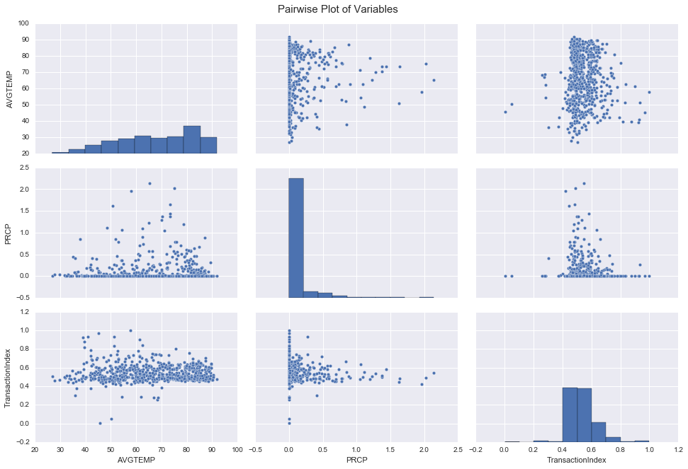

```python
pair=sns.pairplot(df[["AVGTEMP","PRCP",'TransactionIndex']],size=3, aspect=1.5)
pair.fig.text(0.4,1,'Pairwise Plot of Variables', fontsize=15)
```

### Seasonality and Holidays

**Investigating the role of holidays and its effect on transaction volume.**

```python
df.sort_values(['TransactionIndex'],ascending=False)[['transdate','TransactionIndex']].head(10)
```

|  | transdate | TransactionIndex |
| --- | --- | --- |
| 694 | 11/26/14 | 1.000000 |
| 722 | 12/24/14 | 0.968919 |
| 721 | 12/23/14 | 0.932751 |
| 357 | 12/24/13 | 0.928060 |
| 330 | 11/27/13 | 0.924212 |
| 453 | 3/30/14 | 0.901306 |
| 729 | 12/31/14 | 0.877421 |
| 452 | 3/29/14 | 0.838454 |
| 693 | 11/25/14 | 0.831097 |
| 356 | 12/23/13 | 0.818865 |

- Valetines Day (2/14)
- Cesaer Chavez Day (3/30)
- Easter (3/31,4/20)
- Mother's Day (5/10,5/11)
- Thanksgiving (11/28,11/27)
- Christmas (12/25)
- New Year's Eve (12/31)

```python
df.sort_values(['TransactionIndex'],ascending=False)[['transdate','TransactionIndex']].tail(10)
```

|  | transdate | TransactionIndex |
| --- | --- | --- |
| 331 | 11/28/13 | 0.377808 |
| 682 | 11/14/14 | 0.373513 |
| 427 | 3/4/14 | 0.302123 |
| 410 | 2/15/14 | 0.284297 |
| 411 | 2/16/14 | 0.283959 |
| 414 | 2/19/14 | 0.276257 |
| 412 | 2/17/14 | 0.275311 |
| 413 | 2/18/14 | 0.256514 |
| 723 | 12/25/14 | 0.047117 |
| 358 | 12/25/13 | 0.003311 |

**Low transaction volume in February 2014 could potentially be due to local events (winter storm?)**

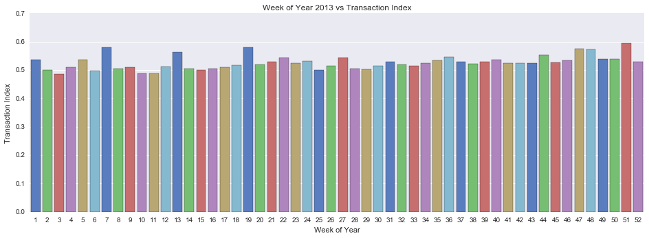

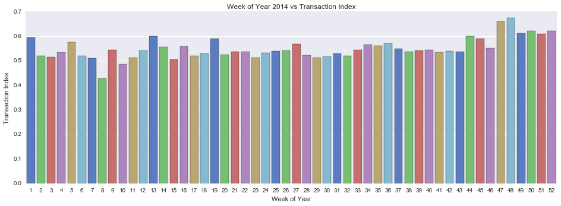

```python
fplot=sns.factorplot(x='weekofyear',y='TransactionIndex',data=df[df.transdate_datetime.dt.year==2013],kind="bar",
               size=4.8, aspect=2.75,ci=None, palette=sns.color_palette("muted",52))
fplot.set(ylim=(0, 0.7))
sns.plt.title('Week of Year 2013 vs Transaction Index');plt.xlabel('Week of Year');plt.ylabel('Transaction Index')

fplot=sns.factorplot(x='weekofyear',y='TransactionIndex',data=df[df.transdate_datetime.dt.year==2014],kind="bar",
               size=4.8, aspect=2.75,ci=None, palette=sns.color_palette("muted",52))
fplot.set(ylim=(0, 0.7))
sns.plt.title('Week of Year 2014 vs Transaction Index');plt.xlabel('Week of Year');plt.ylabel('Transaction Index')
```

**The peaks in the graph fall on major holidays**

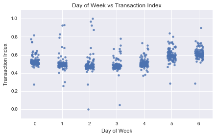

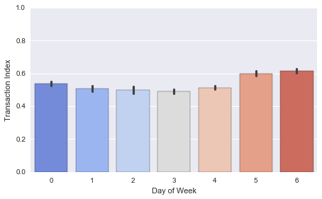

```python
plt.figure(figsize=(7,4))
plot=sns.regplot(x="transdate_dayofweek", y="TransactionIndex", data=df, x_jitter=.15, fit_reg=False)
plot.set(xlim=(-0.5, 6.5));plot.set(ylim=(-0.1, 1.1))
plt.xlabel('Day of Week');plt.ylabel('Transaction Index');sns.plt.title('Day of Week vs Transaction Index')

fplot=sns.factorplot(x="transdate_dayofweek",y='TransactionIndex',data=df,kind='bar',order=[0,1,2,3,4,5,6],
                palette=sns.color_palette("coolwarm", 7), size=4,aspect=1.6)
fplot.set(ylim=(0, 1.0));plt.xlabel('Day of Week');plt.ylabel('Transaction Index')
#0 Monday, 6 Sunday
```

**Note: Transaction Indices >0.8 and <0.2 are holiday related.**

**It appears to be an association of an higher transcation index for weekends than for weekdays. We will see if this is statistically significant later on.**

### Temperature and Precipitation

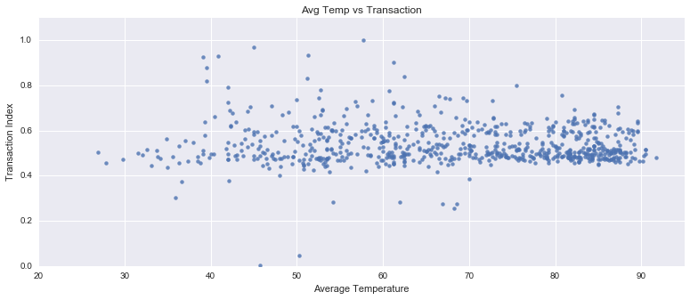

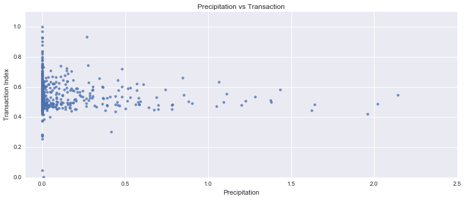

```python
plt.figure(figsize=(13,5))
plot=sns.regplot(x="AVGTEMP", y="TransactionIndex", data=df,fit_reg=False)
plot.set(xlim=(20, 95));plot.set(ylim=(0, 1.1))
plt.xlabel('Average Temperature');plt.ylabel('Transaction Index');sns.plt.title('Avg Temp vs Transaction')

plt.figure(figsize=(13,5))
plot2=sns.regplot(x="PRCP", y="TransactionIndex", data=df,fit_reg=False)
plot2.set(xlim=(-0.1, 2.5));plot2.set(ylim=(0, 1.1))
plt.xlabel('Precipitation');plt.ylabel('Transaction Index');sns.plt.title('Precipitation vs Transaction')
```

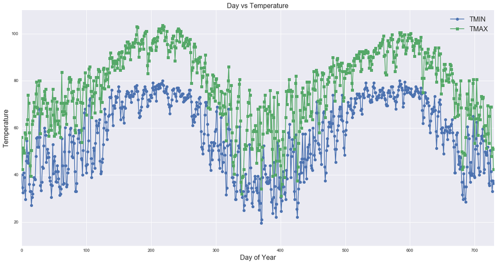

```python
plt.figure(figsize=(20,10))
line_TMIN=plt.plot(df['TMIN'],label="TMIN", marker='o');line_TMAX=plt.plot(df['TMAX'],label="TMAX", marker='s')
plt.xlim(0,730);plt.xlabel('Day of Year',fontsize=16);plt.ylabel('Temperature',fontsize=16);plt.legend(fontsize=16);
plt.title("Day vs Temperature",fontsize=16);plt.show()
```

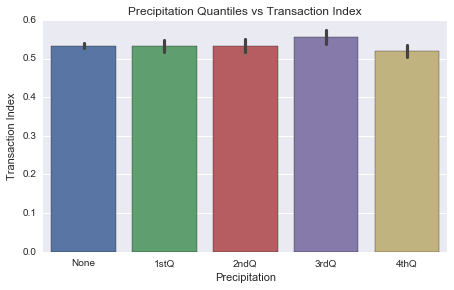

```python
sns.factorplot(x='PRCP_Q',y='TransactionIndex', data=df1,kind="bar", size=4, aspect=1.6,
               order=['None','1stQ','2ndQ','3rdQ','4thQ'])
fplot.set(ylim=(0, 1.0));plt.xlabel('Precipitation');plt.ylabel('Transaction Index')
sns.plt.title('Precipitation Quantiles vs Transaction Index')
# 0.00590551,  0.02559055,  0.10531496,  0.30511811,  2.14173228
# 458,77,69,67,59
```

## Data Exploration Summary

- *The primary factors that drive (and those that don’t drive) Yee-Haw transaction volume.*

The factors in the dataset and their effect on transaction volume:

**Snow** - Snow data was provided as 0 in the dataset and thus is unknown about the relationship between snow and transaction volume.  
**Precipitation** - There appears to be little to no association between precipitation and transaction volume.  
**Temperature** - Temperature is cyclic with the seasons as expected. There appears to be little to no association between temperature and transaction volume.

Findings:

**Holidays** - There appears to be a strong association between transaction volume and days around major holidays.  
**Weekdays vs Weekends** - There appears to be an association of a higher transacation volumne on weekends.

The key factors that drives transaction volume appears to be the **day of the week** (weekdays vs weekends) and days around **major holidays**. Precipitation, snow, and temperature do not appear to have a strong association with driving transaction volume.

- *The overall predictability of Yee-Haw transaction volume as a driver for inventory and resource planning.*

The two factors that appear to drive transaction volume are **day of the week** and **major holidays**. The days with the highest transaction index are days around major holidays. (Valentines Day, Cesar Chavez, Easter, Mother's Day, Thanksgiving, Christmas, New Year's Eve). Also, weekends generally have higher transaction volume during the week than weekdays (except when holidays fall on a weekday).

In terms of predictability, based on the data, the highest transaction days tend to be around the major holidays and towards the end of the year in late November and December.

One thing to note is that major catastrophe events could also have an impact on transaction volume, such as the February 2014 winterstorm event , which appears to have affected the transaction volumes.

## Applying Linear Machine Learning Algorithms

**Next step is to apply methods to model the daily transaction volume. The following machine learning regression algorithms were ran:**

- Linear Regression (RMSE as scoring criteria)
- Decision Tree Regressor (RMSE as scoring criteria)
- Random Forest Regressor (RMSE as scoring criteria)

```python
#import ML packages from sklearn
from sklearn.linear_model import LinearRegression
from sklearn.tree import DecisionTreeRegressor
from sklearn.ensemble import RandomForestRegressor
from sklearn.cross_validation import cross_val_score
#import statsmodel for linear regression output
import statsmodels.formula.api as smf
```

```python
#Load features for training ML models
features=['AVGTEMP','PRCP','transdate_dayofweek_C_0','transdate_dayofweek_C_1','transdate_dayofweek_C_2',\
         'transdate_dayofweek_C_3','transdate_dayofweek_C_4','transdate_dayofweek_C_5','transdate_dayofweek_C_6']
response=['TransactionIndex']
X=df1_ml[features]
y=df1_ml[response]
```

### Cross Validation

- Split the dataset into K equal partitions (or "folds").
- Use fold 1 as the testing set and the union of the other folds as the training set.
- Repeat above steps K times

[figure not shown]

```python
# Linear Regression with 10-fold cross-validation
lm = LinearRegression()
scores = cross_val_score(lm, X, np.ravel(y), cv=10, scoring='mean_squared_error')
print 'Linear Regression Avg RMSE is:%s' %(np.sqrt(-scores).mean())
scores = cross_val_score(lm, X, np.ravel(y), cv=10, scoring='r2')
print 'Linear Regression Avg R^2 is:%s' %(scores.mean())
```

```
Linear Regression Avg RMSE is:0.0530159689454
Linear Regression Avg R^2 is:0.393855824393
```

```python
# Regression tree/Random Forest with 10-fold validation
regr_1 = DecisionTreeRegressor(max_depth=2)
randForest = RandomForestRegressor(n_estimators=10,max_depth=2,random_state=0)
scores = cross_val_score(regr_1, X, np.ravel(y), cv=10, scoring='mean_squared_error')
print 'Decision Tree Avg RMSE is:%s' %(np.sqrt(-scores).mean())
scores = cross_val_score(randForest, X, np.ravel(y), cv=10, scoring='mean_squared_error')
print 'RandomForest Avg RMSE is:%s' %(np.sqrt(-scores).mean())
```

```
Decision Tree Avg RMSE is:0.0550477968393
RandomForest Avg RMSE is:0.0547447508236
```

**The linear regression model results in a lower RMSE of 0.053 (MEAN, STDEV of subset of data is 0.533, 0.073) and a R^2 of ~0.39. 39% of the variance is explained by the model/parameters.**

## Training Full Dataset and Significance Testing

```python
model1=smf.ols(formula='TransactionIndex ~ C(transdate_dayofweek)+ AVGTEMP + PRCP',data=df1)
results1=model1.fit()
print(results1.summary())
```

```
                            OLS Regression Results
==============================================================================
Dep. Variable:       TransactionIndex   R-squared:                       0.418
Model:                            OLS   Adj. R-squared:                  0.412
Method:                 Least Squares   F-statistic:                     63.65
Date:                Mon, 01 Feb 2016   Prob (F-statistic):           2.74e-78
Time:                        15:38:52   Log-Likelihood:                 1044.8
No. Observations:                 717   AIC:                            -2072.
Df Residuals:                     708   BIC:                            -2030.
Df Model:                           8
Covariance Type:            nonrobust
===============================================================================================
                                  coef    std err          t      P>|t|      [95.0% Conf. Int.]
-----------------------------------------------------------------------------------------------
Intercept                       0.5396      0.011     48.476      0.000         0.518     0.561
C(transdate_dayofweek)[T.1]    -0.0382      0.008     -4.816      0.000        -0.054    -0.023
C(transdate_dayofweek)[T.2]    -0.0501      0.008     -6.290      0.000        -0.066    -0.034
C(transdate_dayofweek)[T.3]    -0.0404      0.008     -5.115      0.000        -0.056    -0.025
C(transdate_dayofweek)[T.4]    -0.0215      0.008     -2.722      0.007        -0.037    -0.006
C(transdate_dayofweek)[T.5]     0.0611      0.008      7.710      0.000         0.046     0.077
C(transdate_dayofweek)[T.6]     0.0786      0.008      9.935      0.000         0.063     0.094
AVGTEMP                     -5.421e-05      0.000     -0.386      0.700        -0.000     0.000
PRCP                           -0.0069      0.008     -0.829      0.407        -0.023     0.009
==============================================================================
Omnibus:                      147.050   Durbin-Watson:                   1.006
Prob(Omnibus):                  0.000   Jarque-Bera (JB):             1747.482
Skew:                           0.537   Prob(JB):                         0.00
Kurtosis:                      10.572   Cond. No.                         533.
==============================================================================

Warnings:
[1] Standard Errors assume that the covariance matrix of the errors is correctly specified.
```

## Model Methods and Selection

- *Methodologies for modeling daily Yee-Haw transaction volume in real-time going forward.*

Machine learning algorithms were applied to the dataset in an attempt to generate a robust model for predictions. The following machine learning algorithms were tested on the dataset with 10-fold cross validation: **linear regression, decision tree regressors, and random forest regressors.**

The random forest model generated a similar results as linear regression, however, linear regression models are easier to interpret. The linear regression analysis shows that temperature and precipitation do not show a strong linear association with transaction index. Due to few factors in the dataset that showed a strong association with transaction volume, the linear algorithms tested do not appear to be strong estimators in modeling the daily Yee-Haw transaction volume. The model exhibited an error of 0.75 standard deviation when tested (RMSE of 0.053, mean and std of dataset is 0.533,0.073) and an R squared value of ~0.418 during fitting. This means that 41.8% of the variance can be explained from the model and parameters.

Forecasting can be based on general trends seen in the dataset but modeling daily transaction volumes appear to be difficult based on the current dataset and linear machine learning algorithms.

- *Methodologies for making regular algorithmic recommendations for inventory and resource planning.*

The linear algorithms that were implemented are not robust enough to generate insightful findings. As the best model tested is linear regression which resulted in an R squared value of ~0.418 with RMSE of 0.053. Since the day of the week is the only parameter to show any statistical significance, this results in the linear regression model predicting based on day of week averages.

Current recommendations are based on using day of week averages for non-holidays and to expected the highest transaction days to occur around **major holidays** (such as Thanksgiving, Christmas) for inventory and resource planning.

## Questions

**Are there current issues with inventory surplus/storage in the current pipeline?**  
This could have an affect on the true potential transaction volume that is observed in the dataset.  
**Is there detailed data in terms of the type of inventory that is being sold in the stores?**  
This could assist with proper allocation of inventory.  
**A more detailed breakdown of transaction volume during the day? (daylight vs night time split)**  
This could assist in the resource planning if there is a noticeable difference between daylight and night time transaction volumes.  
**Do all stores sell the same type of inventory? (ordinary market ve gourmet food market)**  
This can assist in knowing the type of inventory.  
**Is there a schedule of when there are sales? (Company wide vs individual stores)**  
This can influence transaction volumes.